[figure not shown]

# Security of Big Data Analitics

### Laboratory 04 "Linear regression"

#### Please insert bellow your firstname, lastnema and ID number and run this cell

Mateusz Wiśniewski 148327

Linear regression is one of the simplest supervised learning algorithms in machine learning. I am sure that if you have studied technical subjects, you have certainly encountered it. It is one of the simplest algorithms commonly used for forecasting and in many places it gives sufficient results. Its biggest advantage is its simple design, which ensures full interpretability of the model.

In this exercise you will learn about the practical use of linear regression using the scikit-learn library, using the example of single parameter linear regression.

# Example of linear regression

1. In the first step, import the required components of the scikit-learn library:

```python
%matplotlib inline
# is a command used in the Jupyter Notebook or JupyterLab interactive environment that
#imports the NumPy and Matplotlib libraries and sets up the display of graphs directly below the code.

# import from the module linear_model LinearRegression class
# This way we don't have to implement the formulas by ourselves
from sklearn.linear_model import LinearRegression

#import from the module metrics mean_squared_error class
from sklearn.metrics import mean_squared_error
import numpy as np
import matplotlib.pyplot as plt
```

2. Preparation of the data on which we will practice The data will be generated as follows: for a linear function in the form y=ax+b for a given set of x values, we will determine the y values, with some additional value added to each determined y value, which we will call noise.

```python
#code
# linear function y=-3x + 3
# 3 = 4, 3 = 2
a = -3
b = 3
max_noise = 40

# running a pseudorandom number generator with a seed of 2 (we set the seed of the generator so that in each
#experiment to have repeatable results, which can be useful when looking for bugs)
# we use the generator available in the numpy library
np.random.seed(2)

# preparing a set of x values. Using the linspace function, we generate the sequence of 61 values from 0 to 70
x = np.linspace(0, 70, num=71)

# determination of a set of y-values. To the y-values determined from the assumed linear function, we will add
# the product of the max_noise variable and a random value in the interval <-1;1> to obtain a certain spread of y-values.
# By omitting this random factor, we would have ideal values fitting the function and therefore finding a
# a linear regression solution would not be needed

y = a * x + b + max_noise * np.random.randn(x.size)
```

3. Plotting of the prepared data in the coordinate system

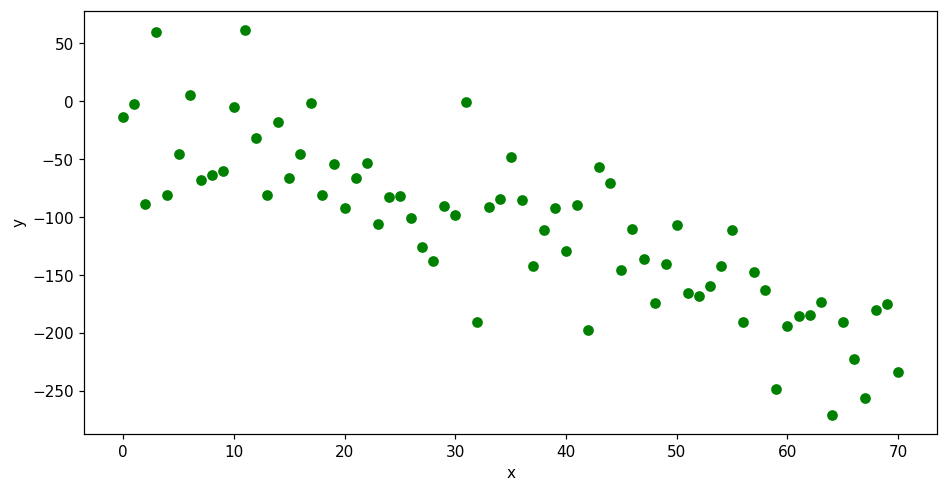

```python
# determination of chart size
fig = plt.figure(figsize=(10, 5), dpi=110)

# scatter is a function of the Matplotlib library that is used to generate scatter plots in two dimensions.
# the parameters of the function are the values of x, y and colour
plt.scatter(x, y, color='green')
# setting axis labels
plt.xlabel('x')
plt.ylabel('y')

# display of data
plt.show()
```

4. Creating a linear regression model object

```python
# Creating model
model = LinearRegression()

# fit() method takes the training data as arguments,
# which can be one array in the case of unsupervised learning, or two arrays in the case of supervised learning
model.fit(x.reshape(-1, 1), y.reshape(-1, 1))

# because the fit function requires data in the form of a single-column array and the data previously generated
# are stored in an array as a single row, the reshape() function should be used in the arguments of the fit() function
# changing the  the form of the input data

# show model weights

print('Model weights: a_predict= ', model.coef_, 'b_predict= ', model.intercept_)

# compare predicted a_predict and b_predict parameters with value a and b
```

```
Model weights: a_predict=  [[-2.88648557]] b_predict=  [-6.97020963]
```

5. Generation of sample data for the model prepared in the 4th step

```python
# data will be determined for three values: 0.06, 35.11, 70.05
# these values are the values from the beginning of the middle and the end of the range of x values used to fit the model
x_predict = np.array([0.06, 35.11, 70.05]).reshape(-1, 1)

# determination value of y_predict
y_predict = model.predict(x_predict)
```

6. Plotting of values used for training and determined on the basis the fitted model

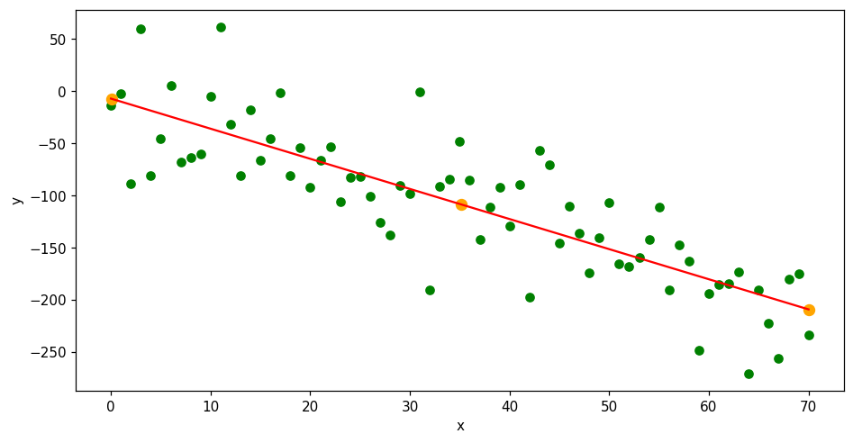

```python
# determination of chart size
fig = plt.figure(figsize=(10, 5), dpi=110)
# setting axis labels
plt.xlabel('x')
plt.ylabel('y')
# plotting of trainnig values
plt.scatter(x, y, color='green')
plt.plot(x.reshape(-1, 1), model.predict(x.reshape(-1, 1)), color='red')
plt.scatter(x_predict.reshape(-1,1), y_predict.reshape(-1,1), color='orange', s=60)
plt.show()
```

7. Determination of mean square error

```python
mean_squared_error(model.predict(x.reshape(-1, 1)), y.reshape(-1, 1))
```

```
np.float64(1550.5593845238466)
```

Review the various steps of creating a linear regression model

### Steps for creating a linear regression model:

- Data loading and preprocessing
- Model training
- Model evaluating
- Making predictions

# Exercise 1

1. Using the code from steps 1-7, run a linear regression on the data determined for a linear function with parameters a and b of your choice. (Copy code and moddify it in new cells)

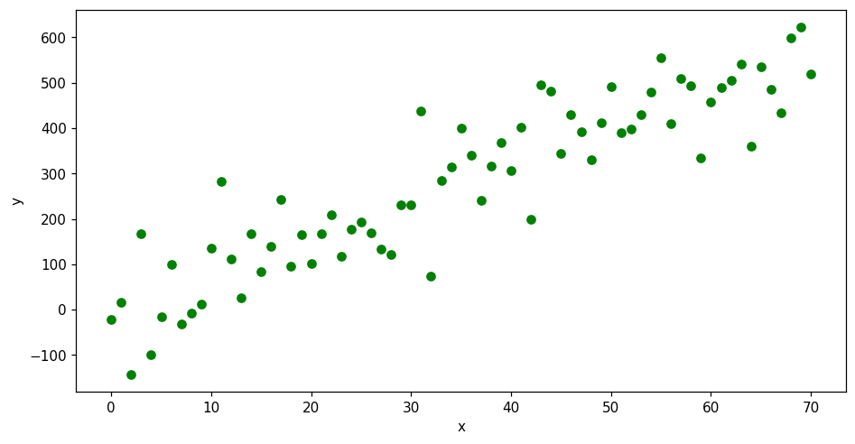

```
Model weights: a_predict=  [[8.22702887]] b_predict=  [-7.94041926]
```

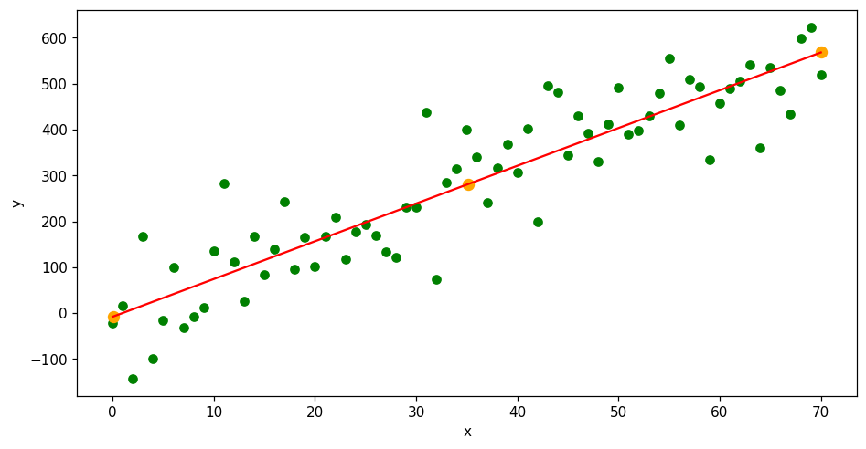

```
np.float64(6202.237538095386)
```

```python
# y=-3x + 3
a = 8
b = 12
max_noise = 80

np.random.seed(2)

x = np.linspace(0, 70, num=71)
y = a * x + b + max_noise * np.random.randn(x.size)

fig = plt.figure(figsize=(10, 5), dpi=110)
plt.scatter(x, y, color='green')
plt.xlabel('x')
plt.ylabel('y')
plt.show()

model = LinearRegression()

model.fit(x.reshape(-1, 1), y.reshape(-1, 1))

print('Model weights: a_predict= ', model.coef_, 'b_predict= ', model.intercept_)
x_predict = np.array([0.06, 35.11, 70.05]).reshape(-1, 1)
y_predict = model.predict(x_predict)

fig = plt.figure(figsize=(10, 5), dpi=110)
plt.xlabel('x')
plt.ylabel('y')
plt.scatter(x, y, color='green')
plt.plot(x.reshape(-1, 1), model.predict(x.reshape(-1, 1)), color='red')
plt.scatter(x_predict.reshape(-1,1), y_predict.reshape(-1,1), color='orange', s=60)
plt.show()

mean_squared_error(model.predict(x.reshape(-1, 1)), y.reshape(-1, 1))
```

your conclusions (if not active click twice):

Linear regression obviously is a great way to model linear functions despite seemingly big noise in the generated data.

# Exercise 2

2. For selected values of a and b, vary the value of max_nose. Check how the value of the squared error depends on this parameter.

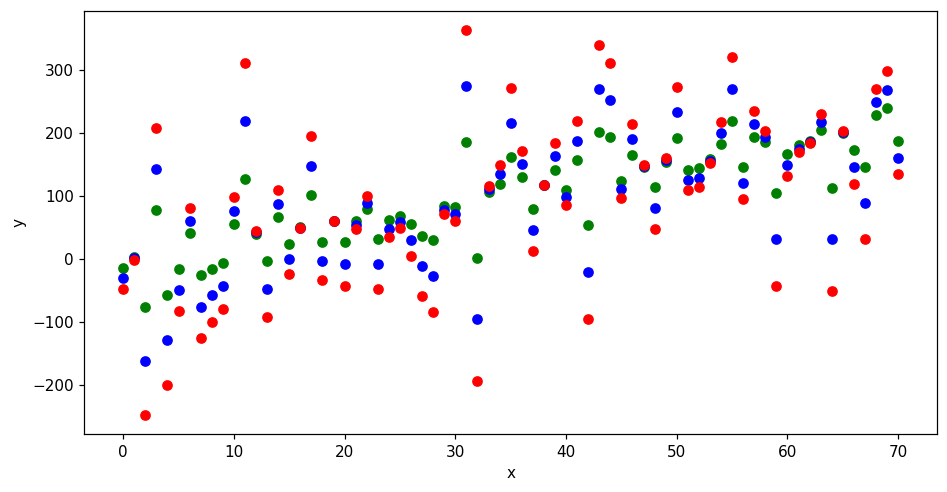

```
Model weights for 40: a_predict=  [[3.11351443]] b_predict=  [-6.97020963]
Model weights for 80: a_predict=  [[3.22702887]] b_predict=  [-16.94041926]
Model weights for 120: a_predict=  [[3.3405433]] b_predict=  [-26.91062889]
```

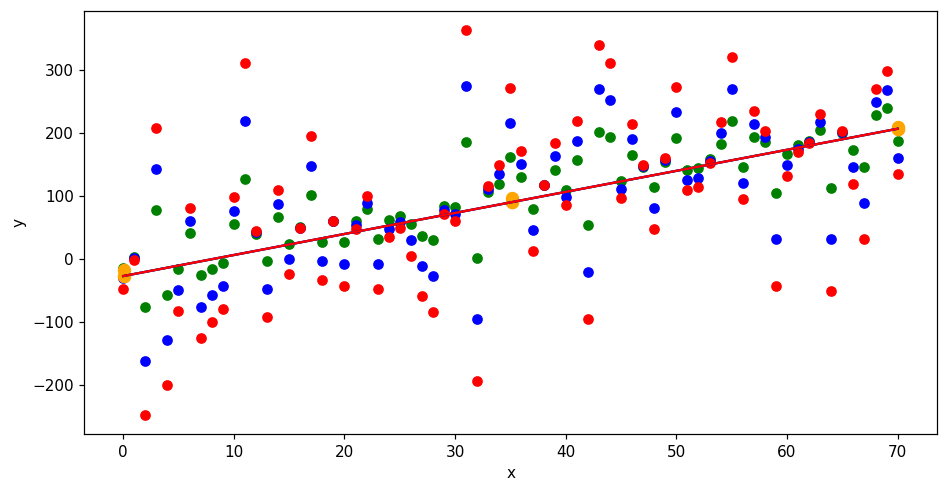

```
MSE for 40, 80, 120:  1716.0729142555003 6243.6159205283 13955.034460714625
```

```python
#code
def linear_function(a, b, max_noise):
    np.random.seed(2)
    x = np.linspace(0, 70, num=71)
    y = a * x + b + max_noise * np.random.randn(x.size)
    return x, y

a = 3
b = 3

x40, y40 = linear_function(a, b, 40)
x80, y80 = linear_function(a, b, 80)
x120, y120 = linear_function(a, b, 120)

fig = plt.figure(figsize=(10, 5), dpi=110)
plt.scatter(x40, y40, color='green')
plt.scatter(x80, y80, color='blue')
plt.scatter(x120, y120, color='red')
plt.xlabel('x')
plt.ylabel('y')
plt.show()

model = LinearRegression()

model.fit(x40.reshape(-1, 1), y40.reshape(-1, 1))
print('Model weights for 40: a_predict= ', model.coef_, 'b_predict= ', model.intercept_)

model.fit(x80.reshape(-1, 1), y80.reshape(-1, 1))
print('Model weights for 80: a_predict= ', model.coef_, 'b_predict= ', model.intercept_)

model.fit(x120.reshape(-1, 1), y120.reshape(-1, 1))
print('Model weights for 120: a_predict= ', model.coef_, 'b_predict= ', model.intercept_)

x_predict = np.array([0.06, 35.11, 70.05]).reshape(-1, 1)

y_predict40 = model.predict(x_predict)
model.fit(x80.reshape(-1, 1), y80.reshape(-1, 1))
y_predict80 = model.predict(x_predict)
model.fit(x120.reshape(-1, 1), y120.reshape(-1, 1))
y_predict120 = model.predict(x_predict)

fig = plt.figure(figsize=(10, 5), dpi=110)
plt.xlabel('x')
plt.ylabel('y')
plt.scatter(x40, y40, color='green')
plt.scatter(x80, y80, color='blue')
plt.scatter(x120, y120, color='red')
plt.plot(x40.reshape(-1, 1), model.predict(x40.reshape(-1, 1)), color='green')
plt.plot(x80.reshape(-1, 1), model.predict(x80.reshape(-1, 1)), color='blue')
plt.plot(x120.reshape(-1, 1), model.predict(x120.reshape(-1, 1)), color='red')
plt.scatter(x_predict.reshape(-1,1), y_predict40.reshape(-1,1), color='orange', s=60)
plt.scatter(x_predict.reshape(-1,1), y_predict80.reshape(-1,1), color='orange', s=60)
plt.scatter(x_predict.reshape(-1,1), y_predict120.reshape(-1,1), color='orange', s=60)
plt.show()

print('MSE for 40, 80, 120: ',
mean_squared_error(model.predict(x40.reshape(-1, 1)), y40.reshape(-1, 1)), mean_squared_error(model.predict(x80.reshape(-1, 1)), y80.reshape(-1, 1)), mean_squared_error(model.predict(x120.reshape(-1, 1)), y120.reshape(-1, 1))
)
```

your conclusions (if not active click twice):

Increase of noise directally impacts the model's accuracy since it cannot fit the complicated shape of sharply spiking data.

# Exercise 3

3. Determine several values of the squared error for several values of max_noise and check what correlation exists between these parameters.

# Exercise 4

Select from https://www.telusinternational.com/insights/ai-data/article/10-open-datasets-for-linear-regression one of the open linear regression datasets described there and then analyze it. Describe the selected dataset and which parameters have been analyzed.

Add any calculations and comments in new cells. After completing the analysis, save the conclusions.

If you think that the collections described in the proposed service are uninteresting, you can choose a collection from the website: https://data.world/datasets/regression

```python
#code
filename = "insurance.csv"
import pandas as pd
from sklearn.preprocessing import LabelEncoder
from sklearn.model_selection import train_test_split

data = pd.read_csv(filename)
data.head()
```

|  | age | sex | bmi | children | smoker | region | charges |
| --- | --- | --- | --- | --- | --- | --- | --- |
| 0 | 19 | female | 27.900 | 0 | yes | southwest | 16884.92400 |
| 1 | 18 | male | 33.770 | 1 | no | southeast | 1725.55230 |
| 2 | 28 | male | 33.000 | 3 | no | southeast | 4449.46200 |
| 3 | 33 | male | 22.705 | 0 | no | northwest | 21984.47061 |
| 4 | 32 | male | 28.880 | 0 | no | northwest | 3866.85520 |

```
MSE: 135983957.4805469
```

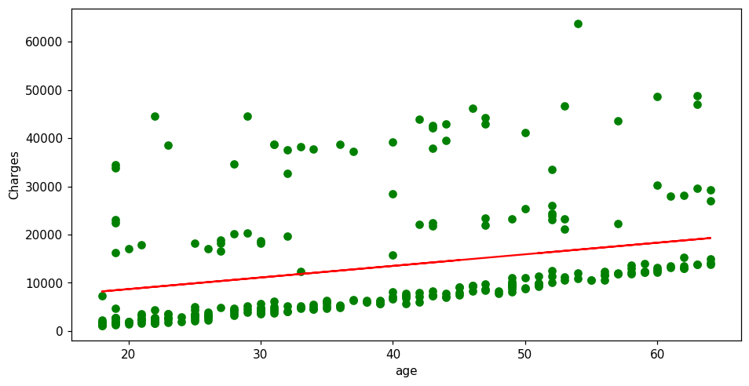

```
MSE: 149085057.03839505
```

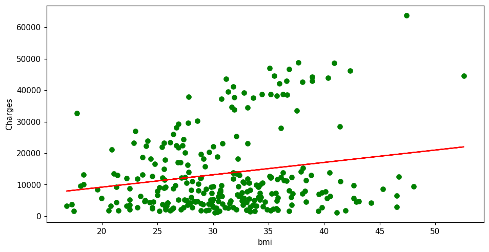

```
MSE: 154985513.03144488
```

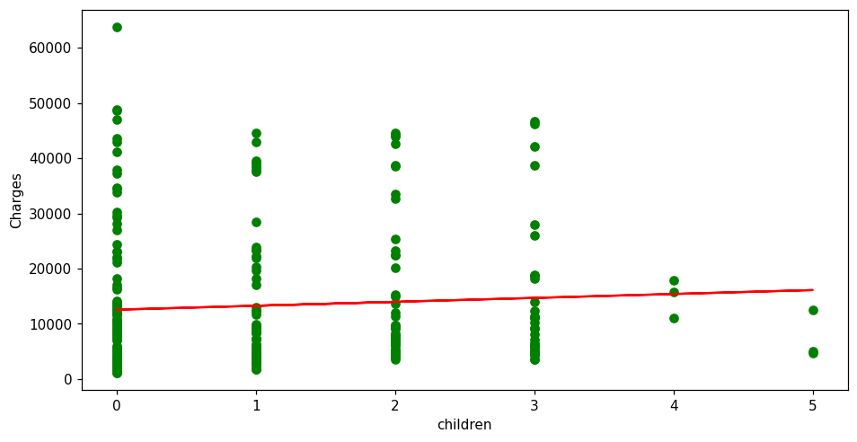

```python
label_encoder = LabelEncoder()
data['sex'] = label_encoder.fit_transform(data['sex'])
data['smoker'] = label_encoder.fit_transform(data['smoker'])

def test_field(field_name):
    X = data[field_name].values.reshape(-1, 1)
    y = data['charges']

    X_train, X_test, y_train, y_test = train_test_split(X, y, test_size=0.2, random_state=42)

    model = LinearRegression()
    model.fit(X_train, y_train)

    y_pred = model.predict(X_test)
    mse = mean_squared_error(y_test, y_pred)

    print(f'MSE: {mse}')

    # Plot
    plt.figure(figsize=(10, 5), dpi=110)
    plt.scatter(X_test, y_test, color='green')
    plt.plot(X_test, model.predict(X_test), color='red')
    plt.xlabel(field_name)
    plt.ylabel('Charges')
    plt.show()

test_field('age')
test_field('bmi')
test_field('children')
```

your conclusions (if not active click twice):

From all numerical values in the dataset, age is the best predictor for insurance charges. The model that was trained happened to be offset from a big clump of linear data by a large number of outliers. Removing them would significally improve the model's performance.